# EDA in R by britta ente

```
##   fixed.acidity volatile.acidity citric.acid residual.sugar chlorides
## 1           7.4             0.70        0.00            1.9     0.076
## 2           7.8             0.88        0.00            2.6     0.098
## 3           7.8             0.76        0.04            2.3     0.092
## 4          11.2             0.28        0.56            1.9     0.075
## 5           7.4             0.70        0.00            1.9     0.076
## 6           7.4             0.66        0.00            1.8     0.075
##   free.sulfur.dioxide total.sulfur.dioxide density   pH sulphates alcohol
## 1                  11                   34  0.9978 3.51      0.56     9.4
## 2                  25                   67  0.9968 3.20      0.68     9.8
## 3                  15                   54  0.9970 3.26      0.65     9.8
## 4                  17                   60  0.9980 3.16      0.58     9.8
## 5                  11                   34  0.9978 3.51      0.56     9.4
## 6                  13                   40  0.9978 3.51      0.56     9.4
##   quality
## 1       5
## 2       5
## 3       5
## 4       6
## 5       5
## 6       5
```

```
##      fixed.acidity volatile.acidity citric.acid residual.sugar chlorides
## 1594           6.8            0.620        0.08            1.9     0.068
## 1595           6.2            0.600        0.08            2.0     0.090
## 1596           5.9            0.550        0.10            2.2     0.062
## 1597           6.3            0.510        0.13            2.3     0.076
## 1598           5.9            0.645        0.12            2.0     0.075
## 1599           6.0            0.310        0.47            3.6     0.067
##      free.sulfur.dioxide total.sulfur.dioxide density   pH sulphates
## 1594                  28                   38 0.99651 3.42      0.82
## 1595                  32                   44 0.99490 3.45      0.58
## 1596                  39                   51 0.99512 3.52      0.76
## 1597                  29                   40 0.99574 3.42      0.75
## 1598                  32                   44 0.99547 3.57      0.71
## 1599                  18                   42 0.99549 3.39      0.66
##      alcohol quality
## 1594     9.5       6
## 1595    10.5       5
## 1596    11.2       6
## 1597    11.0       6
## 1598    10.2       5
## 1599    11.0       6
```

#### which names gt the file?

```
##  [1] "fixed.acidity"        "volatile.acidity"     "citric.acid"
##  [4] "residual.sugar"       "chlorides"            "free.sulfur.dioxide"
##  [7] "total.sulfur.dioxide" "density"              "pH"
## [10] "sulphates"            "alcohol"              "quality"
```

#### lets summarize the data to get an impression of the data

```
##  fixed.acidity   volatile.acidity  citric.acid    residual.sugar
##  Min.   : 4.60   Min.   :0.1200   Min.   :0.000   Min.   : 0.900
##  1st Qu.: 7.10   1st Qu.:0.3900   1st Qu.:0.090   1st Qu.: 1.900
##  Median : 7.90   Median :0.5200   Median :0.260   Median : 2.200
##  Mean   : 8.32   Mean   :0.5278   Mean   :0.271   Mean   : 2.539
##  3rd Qu.: 9.20   3rd Qu.:0.6400   3rd Qu.:0.420   3rd Qu.: 2.600
##  Max.   :15.90   Max.   :1.5800   Max.   :1.000   Max.   :15.500
##    chlorides       free.sulfur.dioxide total.sulfur.dioxide
##  Min.   :0.01200   Min.   : 1.00       Min.   :  6.00
##  1st Qu.:0.07000   1st Qu.: 7.00       1st Qu.: 22.00
##  Median :0.07900   Median :14.00       Median : 38.00
##  Mean   :0.08747   Mean   :15.87       Mean   : 46.47
##  3rd Qu.:0.09000   3rd Qu.:21.00       3rd Qu.: 62.00
##  Max.   :0.61100   Max.   :72.00       Max.   :289.00
##     density             pH          sulphates         alcohol
##  Min.   :0.9901   Min.   :2.740   Min.   :0.3300   Min.   : 8.40
##  1st Qu.:0.9956   1st Qu.:3.210   1st Qu.:0.5500   1st Qu.: 9.50
##  Median :0.9968   Median :3.310   Median :0.6200   Median :10.20
##  Mean   :0.9967   Mean   :3.311   Mean   :0.6581   Mean   :10.42
##  3rd Qu.:0.9978   3rd Qu.:3.400   3rd Qu.:0.7300   3rd Qu.:11.10
##  Max.   :1.0037   Max.   :4.010   Max.   :2.0000   Max.   :14.90
##     quality
##  Min.   :3.000
##  1st Qu.:5.000
##  Median :6.000
##  Mean   :5.636
##  3rd Qu.:6.000
##  Max.   :8.000
```

# Univariate Plots Section

i as a non wine drinker would that that the most important values are the ph value( wikipedia says that the lower the ph value the higher is the acidity), the quality, the alcohol content, the citrid acid( taste bitter and fresh), the residual sugar (taste sweet) and the chloride( taste salty) and the density are the most interesting values in this data set.

lets arrange a few plots with the most important values. #### quality

```
##    Min. 1st Qu.  Median    Mean 3rd Qu.    Max.
##   3.000   5.000   6.000   5.636   6.000   8.000
```

the line above shows us a quality range of 3 till 8. the median is 6 and the mean is nearby with 5.636. the following histogramm shows this.

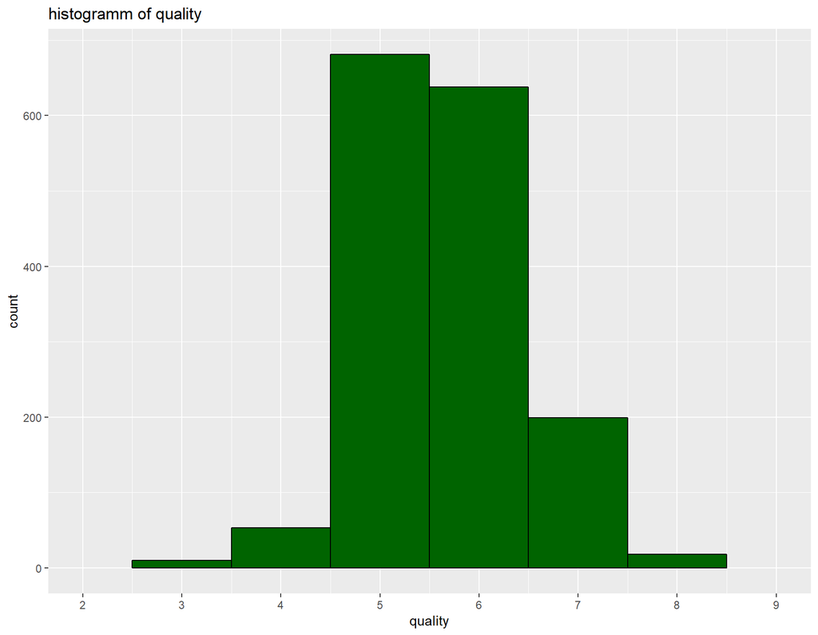

#### residual sugar

```
##    Min. 1st Qu.  Median    Mean 3rd Qu.    Max.
##   0.900   1.900   2.200   2.539   2.600  15.500
```

the line above shows us a residual.sugar range of 0.9 till 15.5. the median is 2.2 and the mean is nearby with 2.539. the following histogramm shows this. the max of 15 is really an outlier. how many sugar values are above 10?

```
##      fixed.acidity volatile.acidity citric.acid residual.sugar chlorides
## 34             6.9            0.605        0.12           10.7     0.073
## 325           10.0            0.490        0.20           11.0     0.071
## 326           10.0            0.490        0.20           11.0     0.071
## 481           10.6            0.280        0.39           15.5     0.069
## 1236           6.0            0.330        0.32           12.9     0.054
## 1245           5.9            0.290        0.25           13.4     0.067
## 1435          10.2            0.540        0.37           15.4     0.214
## 1436          10.2            0.540        0.37           15.4     0.214
## 1475           9.9            0.500        0.50           13.8     0.205
## 1477           9.9            0.500        0.50           13.8     0.205
## 1575           5.6            0.310        0.78           13.9     0.074
##      free.sulfur.dioxide total.sulfur.dioxide density   pH sulphates
## 34                    40                   83 0.99930 3.45      0.52
## 325                   13                   50 1.00150 3.16      0.69
```

[output cut: 21 more lines]

11 wines from 1599 got a residual sugar above ten. this are really outliers.

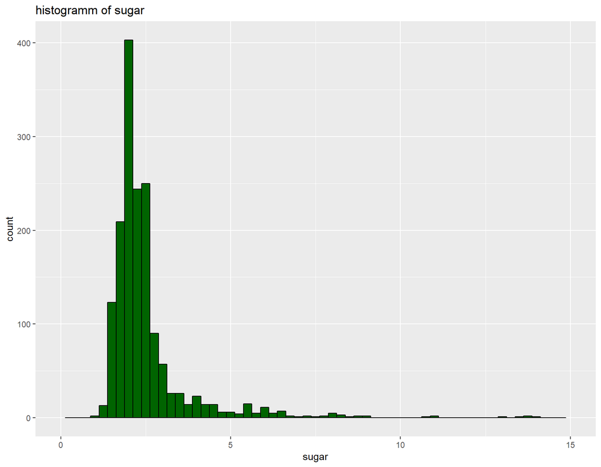

chlorides

```
##    Min. 1st Qu.  Median    Mean 3rd Qu.    Max.
## 0.01200 0.07000 0.07900 0.08747 0.09000 0.61100
```

the line above shows us a chlorides range of 0.012 till 0.611. the median is 0.07900 and the mean is 0.08747. the following histogramm shows this.

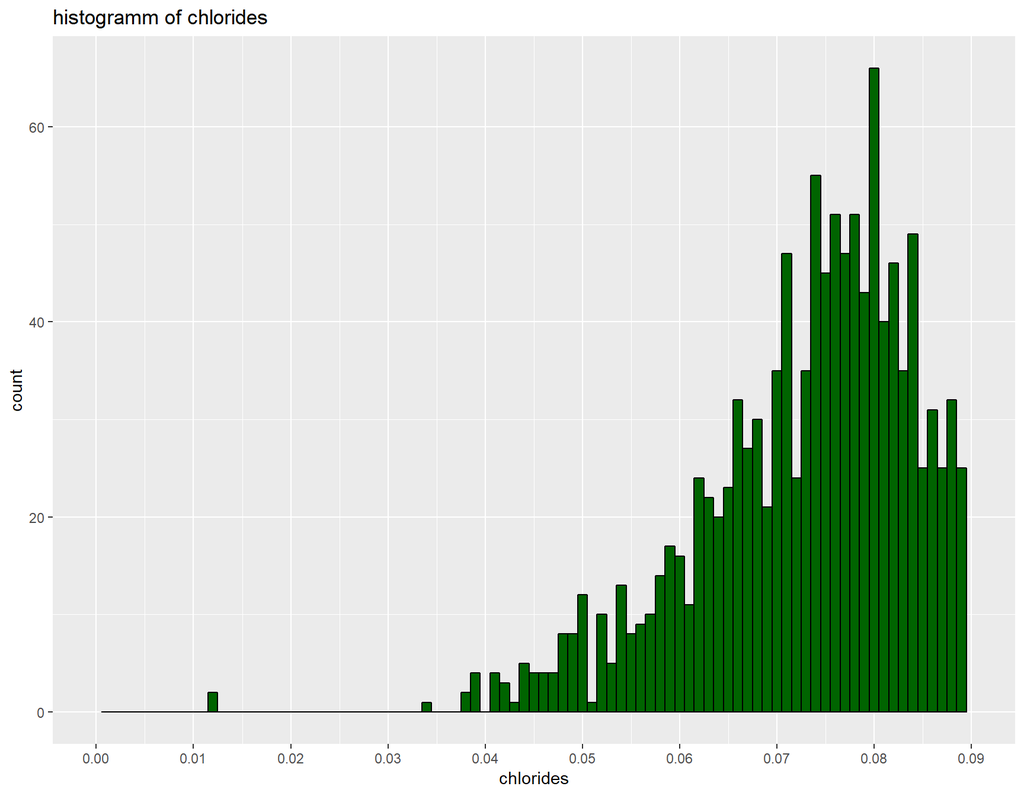

##### density

```
##    Min. 1st Qu.  Median    Mean 3rd Qu.    Max.
##  0.9901  0.9956  0.9968  0.9967  0.9978  1.0037
```

the line above shows us a density range of 0.9901 till 1.0037. the median is 0.9968 and the mean is 0.9967. the histogramm is normal distributed.

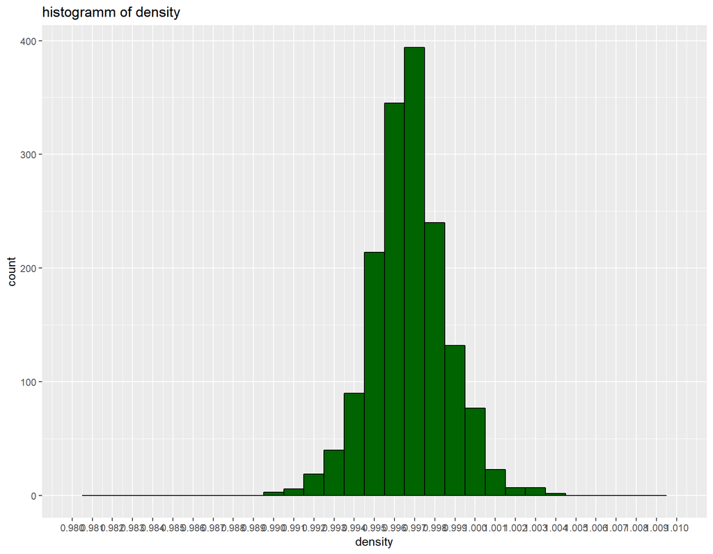

#### alcohol content

```
##    Min. 1st Qu.  Median    Mean 3rd Qu.    Max.
##    8.40    9.50   10.20   10.42   11.10   14.90
```

the line above shows us a alcohol range of 8.4 till 14.90. the median is 10.20 and the mean is 10.42. this histogramm is more right skewed. the most wines got a alcohol content of 10%.

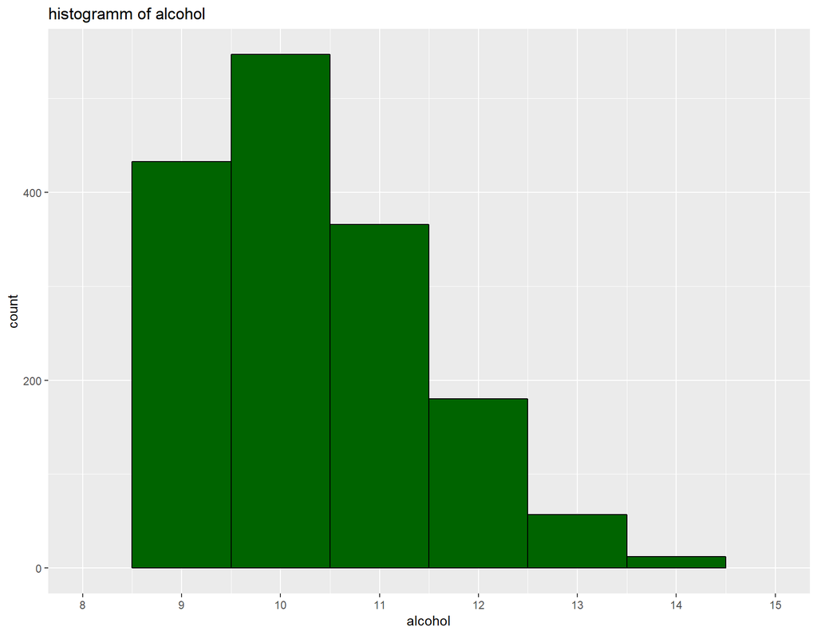

####ph value

```
##    Min. 1st Qu.  Median    Mean 3rd Qu.    Max.
##   2.740   3.210   3.310   3.311   3.400   4.010
```

the line above shows us a ph range of 2.740 till 4.010. the median is 3.310 and the mean is 3.311. this histogramm is normal distributed. the lower the ph value the higher shall be the acidity. we will see this in the second part of our project.

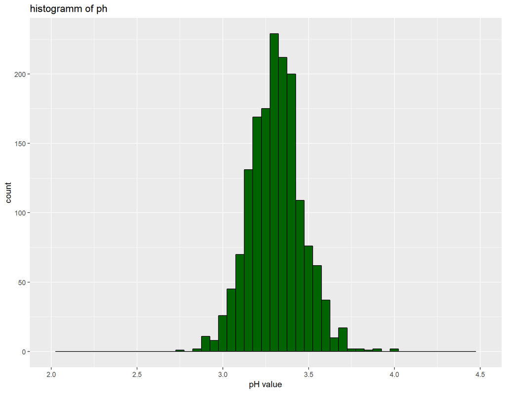

#### citric acid

```
##    Min. 1st Qu.  Median    Mean 3rd Qu.    Max.
##   0.000   0.090   0.260   0.271   0.420   1.000
```

the line above shows us a citric acid range of 0.00 till 1.00. the median is 0.260 and the mean is 0.271.this histogramm is not normal distributed, it has no real form. some wins don´t tast fresh and all and some taste very fresh.

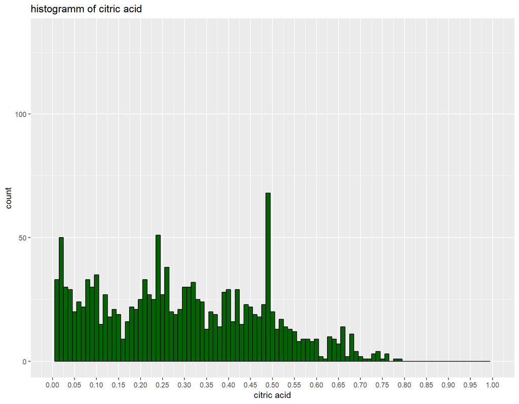

# Bivariate Plots Section

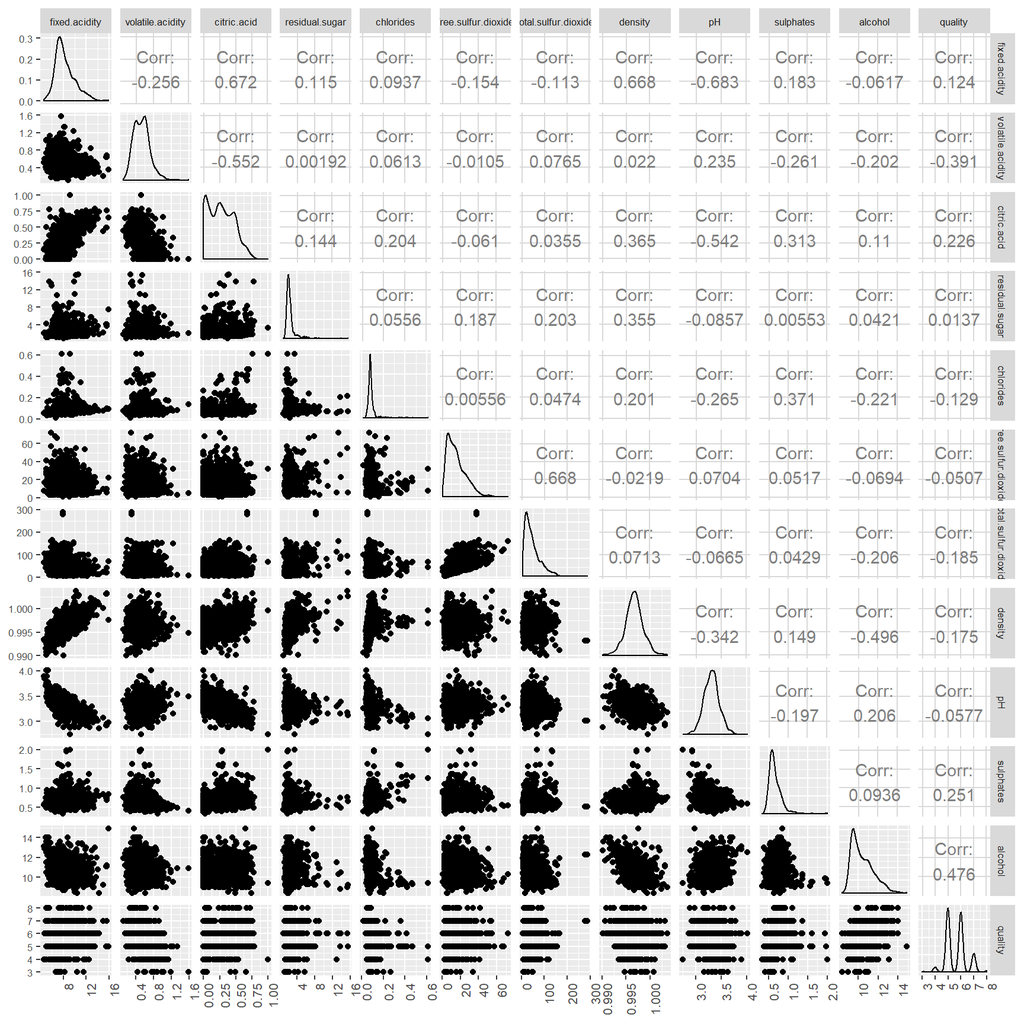

# Bivariate Analysis

#### now lets compare the different values. the main question is what values does a red wine of high quality has? is there any correlation?

#### first test: quality and citric.acid

```
##
##  Pearson's product-moment correlation
##
## data:  pf$quality and pf$citric.acid
## t = 9.2875, df = 1597, p-value < 2.2e-16
## alternative hypothesis: true correlation is not equal to 0
## 95 percent confidence interval:
##  0.1793415 0.2723711
## sample estimates:
##       cor
## 0.2263725
```

the correlation is weak with 0.2263725. lets see it in a plot

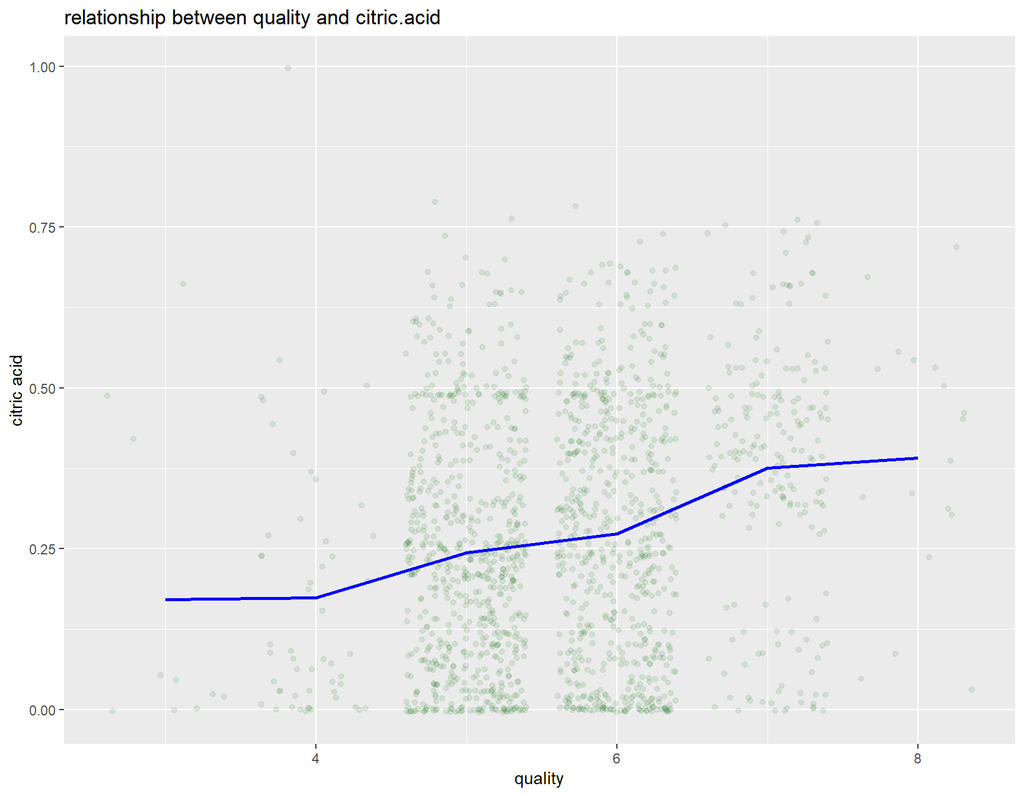

```
## <ScaleContinuousPosition>
##  Range:
##  Limits:    3 --    8
```

second test: quality and alcohol

```
##
##  Pearson's product-moment correlation
##
## data:  pf$quality and pf$alcohol
## t = 21.639, df = 1597, p-value < 2.2e-16
## alternative hypothesis: true correlation is not equal to 0
## 95 percent confidence interval:
##  0.4373540 0.5132081
## sample estimates:
##       cor
## 0.4761663
```

the correlation is moderate with 0.4761663. lets see it in a plot. it is to see that we have a lot of wine with a quality of 5 and the alcohol content of under 10.

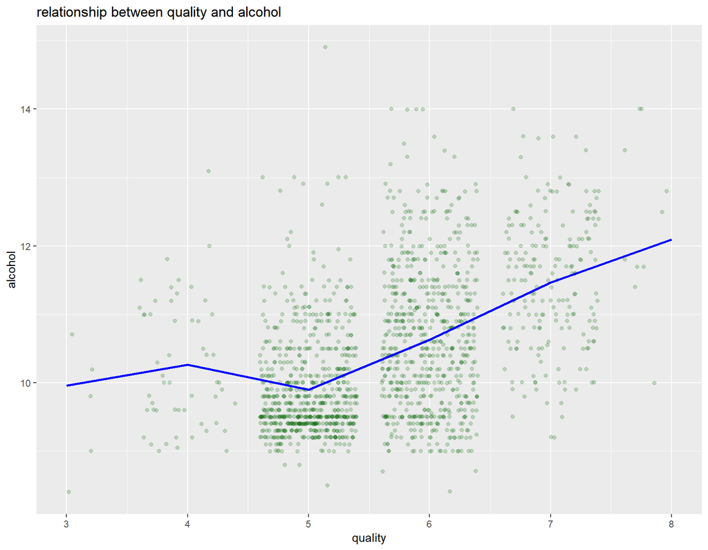

#### third test: quality and residual sugar

```
##
##  Pearson's product-moment correlation
##
## data:  pf$quality and pf$residual.sugar
## t = 0.5488, df = 1597, p-value = 0.5832
## alternative hypothesis: true correlation is not equal to 0
## 95 percent confidence interval:
##  -0.03531327  0.06271056
## sample estimates:
##        cor
## 0.01373164
```

#### the correlation is very weak with 0.01373164. lets see it in a plot.

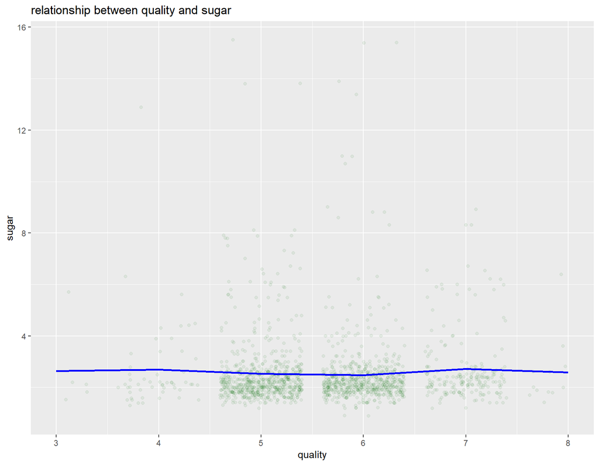

#### fourth test: quality and density

```
##
##  Pearson's product-moment correlation
##
## data:  pf$quality and pf$density
## t = -7.0997, df = 1597, p-value = 1.875e-12
## alternative hypothesis: true correlation is not equal to 0
## 95 percent confidence interval:
##  -0.2220365 -0.1269870
## sample estimates:
##        cor
## -0.1749192
```

#### the correlation is very weak with -0,17494. lets see it in a plot.

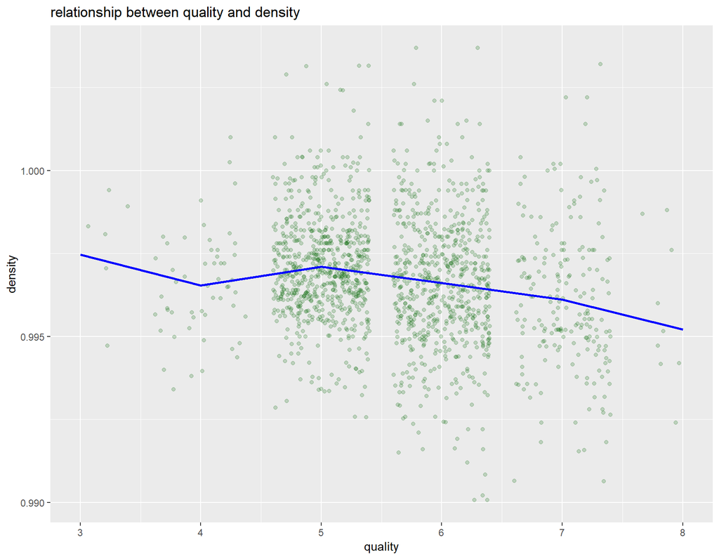

#### fifth test: ph value and acidity

```
##
##  Pearson's product-moment correlation
##
## data:  pf$pH and pf$fixed.acidity
## t = -37.366, df = 1597, p-value < 2.2e-16
## alternative hypothesis: true correlation is not equal to 0
## 95 percent confidence interval:
##  -0.7082857 -0.6559174
## sample estimates:
##        cor
## -0.6829782
```

the correlation is -0,6829782.this means as higher the acidity is as lower is pH value, as to read in the wikipedia article.

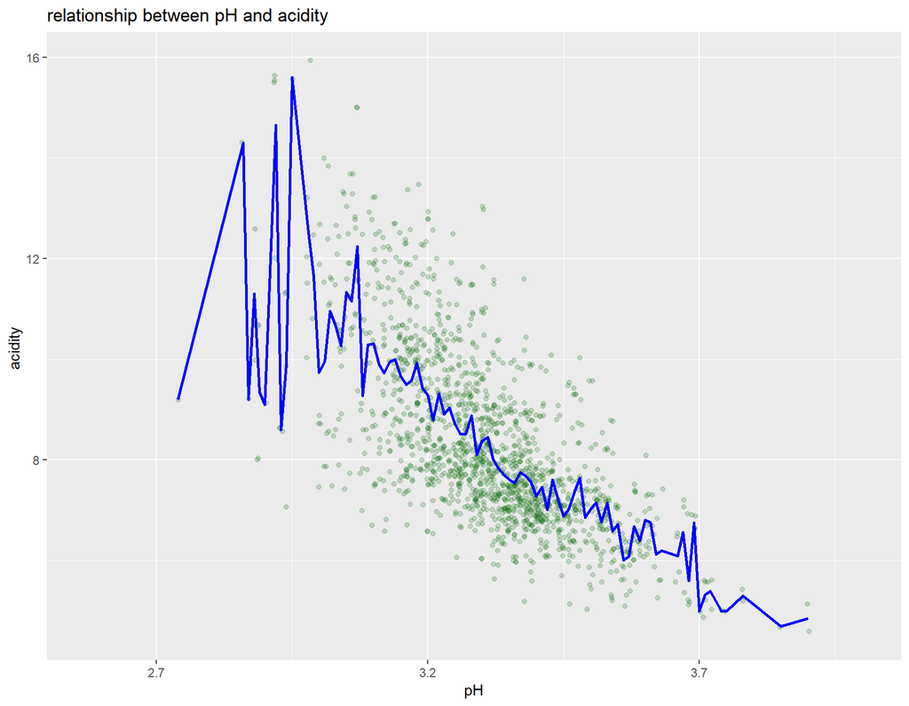

```
##
##  Pearson's product-moment correlation
##
## data:  pf$quality and pf$sulphates
## t = 10.38, df = 1597, p-value < 2.2e-16
## alternative hypothesis: true correlation is not equal to 0
## 95 percent confidence interval:
##  0.2049011 0.2967610
## sample estimates:
##       cor
## 0.2513971
```

[figure not shown]

#### seventh test: density and alcohol

```
##
##  Pearson's product-moment correlation
##
## data:  pf$density and pf$alcohol
## t = -22.838, df = 1597, p-value < 2.2e-16
## alternative hypothesis: true correlation is not equal to 0
## 95 percent confidence interval:
##  -0.5322547 -0.4583061
## sample estimates:
##        cor
## -0.4961798
```

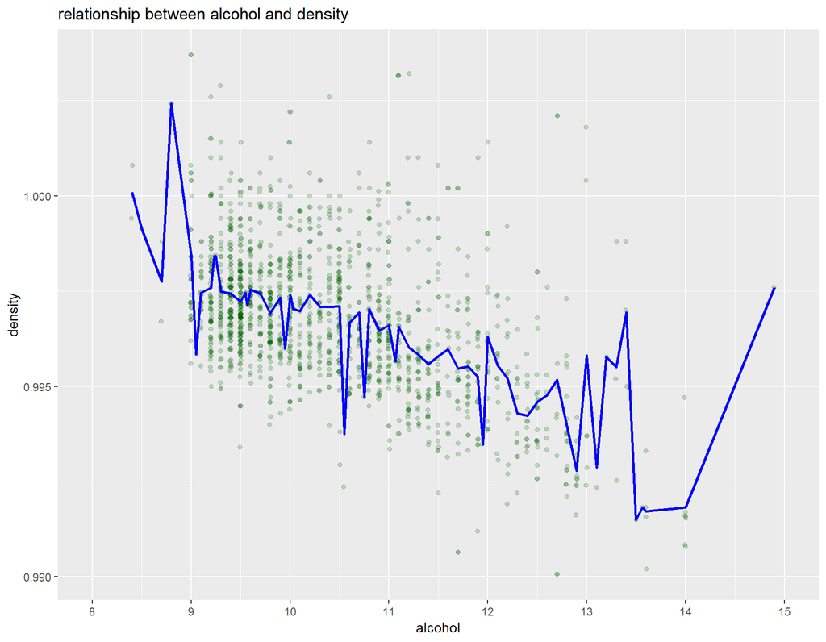

#### eight test: quality and chlorides

```
##
##  Pearson's product-moment correlation
##
## data:  pf$quality and pf$chlorides
## t = -5.1948, df = 1597, p-value = 2.313e-07
## alternative hypothesis: true correlation is not equal to 0
## 95 percent confidence interval:
##  -0.17681041 -0.08039344
## sample estimates:
##        cor
## -0.1289066
```